# Result notes

Yuta Suzuki

4/23/2021

# Article information

Pupil constriction in the glare illusion modulates the steady-state visual evoked potentials

Yuta Suzuki, Minami Tetsuto, Shigeki Nakauchi

*Corresponding author: Yuta Suzuki

# Figure 1

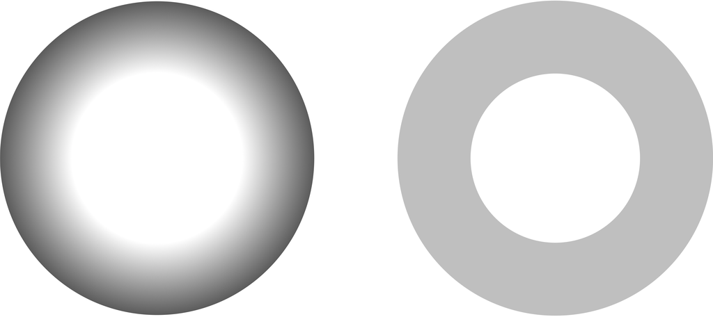

Fig. 1. Glare illusion.The glare illusion consists of a luminance gradation in the periphery. The central region of the glare illusion (left) typically appears brighter than the corresponding control stimulus (right) despite both having the same luminance.

# Figure 2

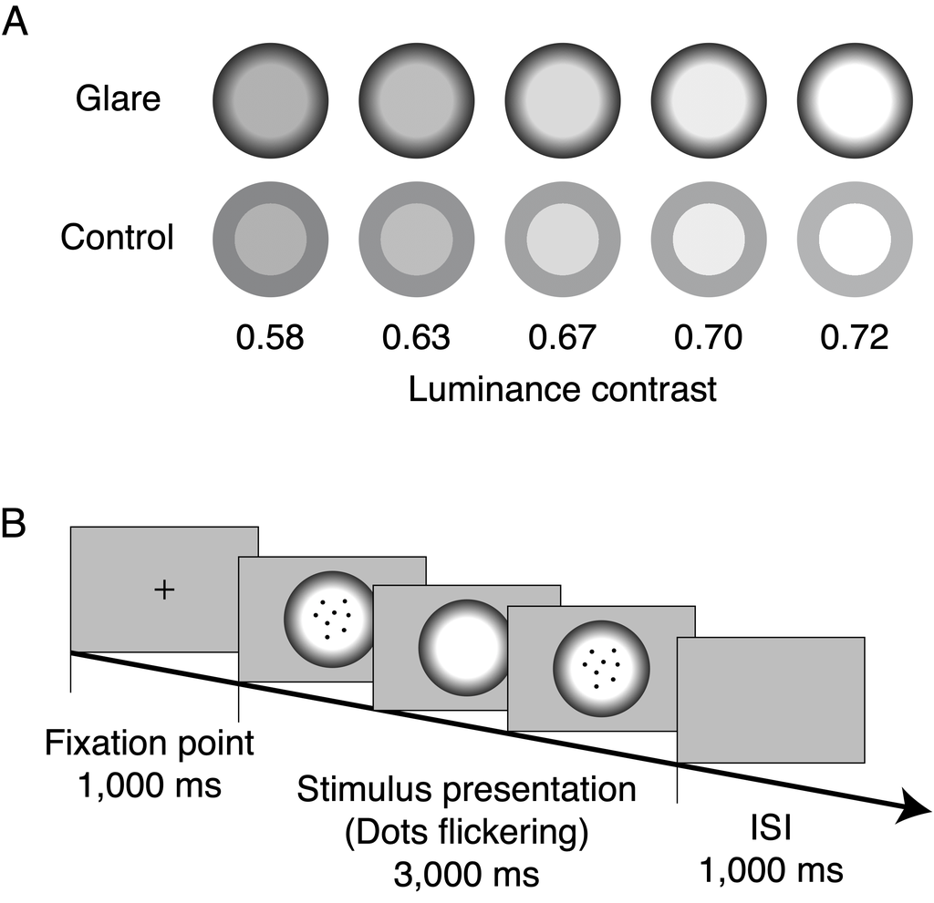

Fig. 2. Experimental stimuli and design of Experiments 1 and 2.(A)Examples of glare stimuli (above) and control stimuli (below) in five luminance contrast conditions used in Experiment 1 and 2. (B) The identical experiment design was used in both Experiment 1 and 2. Each trial included the presentation of the fixation point for 1000 ms and the presentation of the stimulus (glare or control condition) for 3000 ms. Each trial was separated by an inter-stimulus interval (ISI) of 1000 ms. Participants were instructed to focus on the flickering dots.